# Módulo IV. Aprendizaje Automático

Práctica

DSLAB

23 de abril de 2022

# 1 Introducción

En esta práctica vamos a estudiar la detección de intrusiones, que puede ser modelada como un problema de clasificación binaria. Es decir, el objetivo es determinar si el tráfico de la red es un comportamiento anormal o no.

```r
library(class)
library(dplyr)
library(ggplot2)
```

# 2 Los Datos

El conjunto de datos a auditar consiste en una amplia variedad de intrusiones simuladas en un entorno de red militar. Se creó un entorno para adquirir datos de volcado de TCP/IP sin procesar para una red simulando una LAN típica de las Fuerzas Aéreas estadounidenses. La LAN se enfocó como un entorno real y se atacó con múltiples ataques.

Una conexión es una secuencia de paquetes TCP que comienzan y terminan en algún momento entre los cuales los datos fluyen hacia y desde una dirección IP de origen a una dirección IP de destino bajo algún protocolo bien definido. Además, cada conexión se etiqueta como *normal* o como *ataque* con exactamente un tipo de ataque específico. Cada registro de conexión consta de unos 100 bytes.

Para cada conexión TCP/IP, se obtienen 41 características cuantitativas y cualitativas de los datos normales y de ataque (3 cualitativas y 38 cuantitativas). La variable de clase tiene dos categorías - Normal - Anómala

```r
Train_data <- read.csv("./datos/Train_data.csv")

Test_data <-  read.csv("./datos/Test_data.csv")
```

Vamos a ver los primeros datos:

```r
head(Train_data)
```

|  | duration | protocol_type | service | flag | src_bytes | dst_bytes | land | wrong_fragment | urgent | hot | num_failed_logins | logged_in | num_compromised | root_shell | su_attempted | num_root | num_file_creations | num_shells | num_access_files | num_outbound_cmds | is_host_login | is_guest_login | count | srv_count | serror_rate | srv_serror_rate | rerror_rate | srv_rerror_rate | same_srv_rate | … |
| --- | --- | --- | --- | --- | --- | --- | --- | --- | --- | --- | --- | --- | --- | --- | --- | --- | --- | --- | --- | --- | --- | --- | --- | --- | --- | --- | --- | --- | --- | --- |
| 1 | 0 | tcp | ftp_data | SF | 491 | 0 | 0 | 0 | 0 | 0 | 0 | 0 | 0 | 0 | 0 | 0 | 0 | 0 | 0 | 0 | 0 | 0 | 2 | 2 | 0.0 | 0.0 | 0 | 0 | 1.00 | … |
| 2 | 0 | udp | other | SF | 146 | 0 | 0 | 0 | 0 | 0 | 0 | 0 | 0 | 0 | 0 | 0 | 0 | 0 | 0 | 0 | 0 | 0 | 13 | 1 | 0.0 | 0.0 | 0 | 0 | 0.08 | … |
| 3 | 0 | tcp | private | S0 | 0 | 0 | 0 | 0 | 0 | 0 | 0 | 0 | 0 | 0 | 0 | 0 | 0 | 0 | 0 | 0 | 0 | 0 | 123 | 6 | 1.0 | 1.0 | 0 | 0 | 0.05 | … |
| 4 | 0 | tcp | http | SF | 232 | 8153 | 0 | 0 | 0 | 0 | 0 | 1 | 0 | 0 | 0 | 0 | 0 | 0 | 0 | 0 | 0 | 0 | 5 | 5 | 0.2 | 0.2 | 0 | 0 | 1.00 | … |
| 5 | 0 | tcp | http | SF | 199 | 420 | 0 | 0 | 0 | 0 | 0 | 1 | 0 | 0 | 0 | 0 | 0 | 0 | 0 | 0 | 0 | 0 | 30 | 32 | 0.0 | 0.0 | 0 | 0 | 1.00 | … |
| 6 | 0 | tcp | private | REJ | 0 | 0 | 0 | 0 | 0 | 0 | 0 | 0 | 0 | 0 | 0 | 0 | 0 | 0 | 0 | 0 | 0 | 0 | 121 | 19 | 0.0 | 0.0 | 1 | 1 | 0.16 | … |

# 3 EDA

En primer lugar estudiamos las variables de la base de datos:

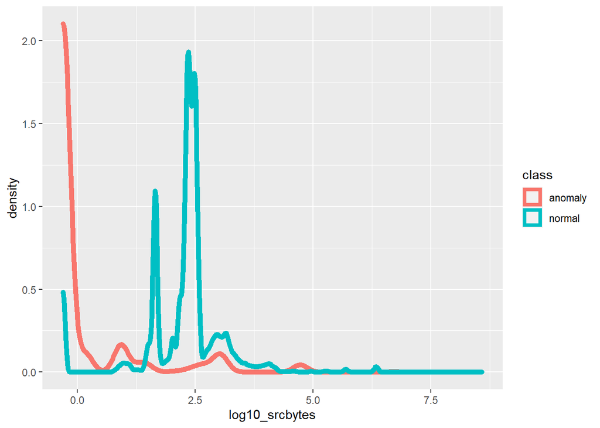

```r
p2 <- Train_data %>% mutate(log10_srcbytes = log10(src_bytes+0.5)) %>%
  select(class, log10_srcbytes) %>%
  na.omit() %>%
  ggplot(aes(x=log10_srcbytes, colour=class)) +
    geom_density(lwd=2)
p2
```

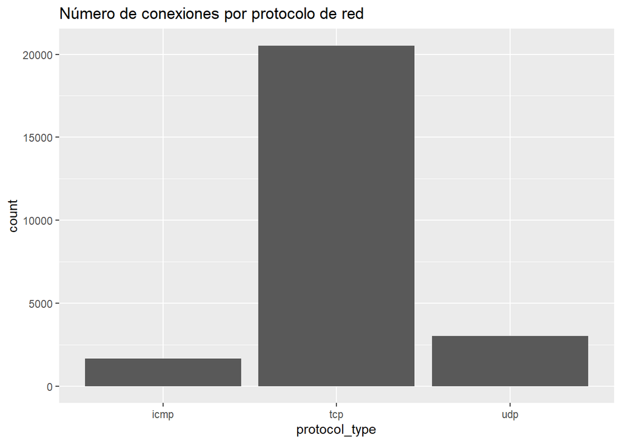

```r
ggplot(Train_data, aes(protocol_type)) + geom_bar()+ ggtitle("Número de conexiones por protocolo de red")
```